# Übung 1 - Recap

## Übung 8 (3 Punkte)

- Visualisiere das Modell

```r
plot(nn)
```

[output not shown]

- Prognostiziere Ergebnisse mit dem Testset.

```r
nn_preds <- compute(nn, test[1:13])
```

- Berechne MSE  
  Beachte, dass jetzt die prognostizierte Werte als auch Testwerte zuerst denormalisiert werden müssen. Dh die vorherige Normalisierung muss jetzt rückwärts berechnet werden.

```r
true.predictions <- nn_preds$net.result *(max(df$medv) - min(df$medv)) + min(df$medv)
test.r <- (test$medv) * max(df$medv) - min(df$medv) + min(df$medv)
MSE.nn <- sum((test.r - true.predictions)^2)/nrow(test)
MSE.nn
```

```
## [1] 24.1242
```

- Generiere jetzt ein anderes Traingset und ein anderes Testset mit den vorhin generierten Indizes, aber diesmal mit originalen, nicht-normalisierten Daten.

```r
df$chas <- as.double(df$chas)
df$rad <- as.double(df$rad)
head(df)
```

|  | crim | zn | indus | chas | nox | rm | age | dis | rad | tax | ptratio | black | lstat | medv |
| --- | --- | --- | --- | --- | --- | --- | --- | --- | --- | --- | --- | --- | --- | --- |
| 1 | 0.00632 | 18 | 2.31 | 0 | 0.538 | 6.575 | 65.2 | 4.0900 | 1 | 296 | 15.3 | 396.90 | 4.98 | 24.0 |
| 2 | 0.02731 | 0 | 7.07 | 0 | 0.469 | 6.421 | 78.9 | 4.9671 | 2 | 242 | 17.8 | 396.90 | 9.14 | 21.6 |
| 3 | 0.02729 | 0 | 7.07 | 0 | 0.469 | 7.185 | 61.1 | 4.9671 | 2 | 242 | 17.8 | 392.83 | 4.03 | 34.7 |
| 4 | 0.03237 | 0 | 2.18 | 0 | 0.458 | 6.998 | 45.8 | 6.0622 | 3 | 222 | 18.7 | 394.63 | 2.94 | 33.4 |
| 5 | 0.06905 | 0 | 2.18 | 0 | 0.458 | 7.147 | 54.2 | 6.0622 | 3 | 222 | 18.7 | 396.90 | 5.33 | 36.2 |
| 6 | 0.02985 | 0 | 2.18 | 0 | 0.458 | 6.430 | 58.7 | 6.0622 | 3 | 222 | 18.7 | 394.12 | 5.21 | 28.7 |

```r
train <- df[split,]
test <-  df[-split,]

n <- names(train)
f <- as.formula(paste("medv ~", paste(n[!n %in% "medv"], collapse = " + ")))
nn_2 <- neuralnet(f, data = train, hidden = c(10))
```

```r
plot(nn)
nn_preds_2 <- compute(nn_2, test[1:13])

MSE.nn_2 <- sum((test$medv - nn_preds_2$net.result)^2)/nrow(test)
MSE.nn_2
```

```
## [1] 89.31624
```

## Übung 9 (3 Punkte)

- OLS Modell Stelle ein OLS Regressionsmodell auf und führe Summary des Modells aus.

```r
ols_model <- train(medv~., data = df, method = "lm")
summary(ols_model)
```

```
##
## Call:
## lm(formula = .outcome ~ ., data = dat)
##
## Residuals:
##     Min      1Q  Median      3Q     Max
## -15.595  -2.730  -0.518   1.777  26.199
##
## Coefficients:
##               Estimate Std. Error t value Pr(>|t|)
## (Intercept)  3.646e+01  5.103e+00   7.144 3.28e-12 ***
## crim        -1.080e-01  3.286e-02  -3.287 0.001087 **
## zn           4.642e-02  1.373e-02   3.382 0.000778 ***
## indus        2.056e-02  6.150e-02   0.334 0.738288
## chas         2.687e+00  8.616e-01   3.118 0.001925 **
## nox         -1.777e+01  3.820e+00  -4.651 4.25e-06 ***
## rm           3.810e+00  4.179e-01   9.116  < 2e-16 ***
## age          6.922e-04  1.321e-02   0.052 0.958229
## dis         -1.476e+00  1.995e-01  -7.398 6.01e-13 ***
## rad          3.060e-01  6.635e-02   4.613 5.07e-06 ***
## tax         -1.233e-02  3.760e-03  -3.280 0.001112 **
## ptratio     -9.527e-01  1.308e-01  -7.283 1.31e-12 ***
## black        9.312e-03  2.686e-03   3.467 0.000573 ***
## lstat       -5.248e-01  5.072e-02 -10.347  < 2e-16 ***
## ---
## Signif. codes:  0 '***' 0.001 '**' 0.01 '*' 0.05 '.' 0.1 ' ' 1
##
## Residual standard error: 4.745 on 492 degrees of freedom
## Multiple R-squared:  0.7406, Adjusted R-squared:  0.7338
## F-statistic: 108.1 on 13 and 492 DF,  p-value: < 2.2e-16
```

- Prognostiziere Ergebnisse des OLS Modells mit dem Testset. (Funktion predict)

```r
lm_preds = predict(ols_model, test)
```

- Berechne MSE für das OLS Modell

```r
MSE.lm <- sum((test$medv - lm_preds)^2)/nrow(test)
MSE.lm
```

```
## [1] 24.96294
```

## Übung 10 (3 Punkte)

Vergleiche NN MSE und OLS MSE.

```r
models <- c("NN 1", "NN 2", "OLS")
mse <- c(MSE.nn, MSE.nn_2, MSE.lm)
table_MSE <- data.frame(models, mse)
table_MSE
```

| models | mse |
| --- | --- |
| NN 1 | 24.12420 |
| NN 2 | 89.31624 |
| OLS | 24.96294 |

- Visualisiere die Modelle

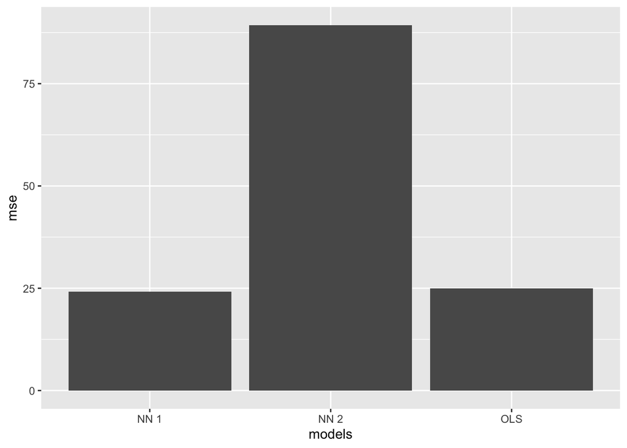

```r
ggplot(table_MSE, aes(x=models, y=mse)) + geom_histogram(stat="identity")
```